# Spatial analyses of 2020-21 excess mortality in CH

Mortality data preparation (*Wohnort* based)

# Mortality data 2015-2021

Custom file delivered by BfS covering 2021 period and standardizing municipalities to Jul 2021.

Using **Wohnort** (*the municipality where the person lived*) as unit of analysis.

```r
w_deaths_2015_2021 <- read_csv("data-raw/BfS-closed/monthly_deaths/13OCT21_Lieferung_Panczak_Wohnort.zip",
                               col_types = cols(year = col_integer(),
                                                month = col_integer(),
                                                COUNT = col_integer()),
                               locale = readr::locale(encoding = "latin1")) %>%
  mutate(sex = if_else(sex == "F", "Female", "Male"),
         nationality = if_else(nationality == "Schweiz", "Swiss", "Foreigner")) %>%
  select(-canton, -community) %>%
  rename(GMDNAME = wohnort,
         canton = wohnkanton) %>%
  # hyphen in name >> doesnt link to spatial data
  mutate(GMDNAME = if_else(GMDNAME == "La Grande-Béroche", "La Grande Béroche", GMDNAME)) %>%
  # name change? >> resolved with Cordula
  mutate(GMDNAME = if_else(GMDNAME == "Klosters-Serneus", "Klosters", GMDNAME)) %>%
  group_by(year, month, canton, GMDNAME, agegroup, sex) %>%
  summarise(deaths = sum(COUNT)) %>%
  ungroup()
```

Description of data:

```
The data contains 267576 observations of the following 7 variables:

  - year: n = 267576, Mean = 2017.81, SD = 1.89, Median = 2018.00, MAD = 2.97, range: [2015, 2021], Skewness = 0.03, Kurtosis = -1.19, 0% missing
  - month: n = 267576, Mean = 6.23, SD = 3.53, Median = 6.00, MAD = 4.45, range: [1, 12], Skewness = 0.12, Kurtosis = -1.25, 0% missing
  - canton: 26 entries, such as BE (14.35%); ZH (12.23%); AG (9.37%) and 23 others (0 missing)
  - GMDNAME: 2159 entries, such as Zürich (0.46%); Genève (0.39%); Basel (0.38%) and 2156 others (0 missing)
  - agegroup: 10 entries, such as [80-90) (31.12%); [90-116) (22.49%); [70-80) (21.04%) and 7 others (0 missing)
  - sex: 2 entries, such as Male (51.57%); Female (48.43%); NA (0 missing)
  - deaths: n = 267576, Mean = 1.66, SD = 2.58, Median = 1.00, MAD = 0.00, range: [1, 124], Skewness = 13.11, Kurtosis = 267.13, 0% missing
```

Data summary

| Name | w_deaths_2015_2021 |
| --- | --- |
| Number of rows | 267576 |
| Number of columns | 7 |
| _______________________ |  |
| Column type frequency: |  |
| character | 4 |
| numeric | 3 |
| ________________________ |  |
| Group variables | None |

**Variable type: character**

| skim_variable | n_missing | complete_rate | min | max | empty | n_unique | whitespace |
| --- | --- | --- | --- | --- | --- | --- | --- |
| canton | 0 | 1 | 2 | 2 | 0 | 26 | 0 |
| GMDNAME | 0 | 1 | 2 | 27 | 0 | 2159 | 0 |
| agegroup | 0 | 1 | 6 | 8 | 0 | 10 | 0 |
| sex | 0 | 1 | 4 | 6 | 0 | 2 | 0 |

**Variable type: numeric**

| skim_variable | n_missing | complete_rate | mean | sd | p0 | p25 | p50 | p75 | p100 | hist |
| --- | --- | --- | --- | --- | --- | --- | --- | --- | --- | --- |
| year | 0 | 1 | 2017.81 | 1.89 | 2015 | 2016 | 2018 | 2019 | 2021 | ▇▅▅▅▆ |
| month | 0 | 1 | 6.23 | 3.53 | 1 | 3 | 6 | 9 | 12 | ▇▅▅▅▇ |
| deaths | 0 | 1 | 1.66 | 2.58 | 1 | 1 | 1 | 2 | 124 | ▇▁▁▁▁ |

445,199 deaths by year:

|  | year | Deaths |
| --- | --- | --- |
| 1 | 2015 | 67617 |
| 2 | 2016 | 64948 |
| 3 | 2017 | 66982 |
| 4 | 2018 | 67096 |
| 5 | 2019 | 67793 |
| 6 | 2020 | 76181 |
| 7 | 2021 | 34582 |

# Codes of geographical areas

There were 2,163 municipalities in Jul 2021 in CH.

4 had no deaths recorded during the study period.

|  | GMDNAME | KTNAME |
| --- | --- | --- |
| 1 | Clavaleyres | BE |
| 2 | Rüte | AI |
| 3 | Geltwil | AG |
| 4 | Rossenges | VD |

# Age groups

Original age groups:

```
agegroup <character>
# total N=267576 valid N=267576 mean=8.25 sd=1.65

Value    |     N | Raw % | Valid % | Cum. %
-------------------------------------------
[0-10)   |  2295 |  0.86 |    0.86 |   0.86
[10-20)  |   824 |  0.31 |    0.31 |   1.17
[20-30)  |  2092 |  0.78 |    0.78 |   1.95
[30-40)  |  3096 |  1.16 |    1.16 |   3.10
[40-50)  |  7299 |  2.73 |    2.73 |   5.83
[50-60)  | 18713 |  6.99 |    6.99 |  12.83
[60-70)  | 33500 | 12.52 |   12.52 |  25.35
[70-80)  | 56302 | 21.04 |   21.04 |  46.39
[80-90)  | 83267 | 31.12 |   31.12 |  77.51
[90-116) | 60188 | 22.49 |   22.49 | 100.00
<NA>     |     0 |  0.00 |    <NA> |   <NA>
```

```r
w_deaths_2015_2021 %<>%
  mutate(
    age = case_when(
      agegroup == "[0-10)" ~   "<40",
      agegroup == "[10-20)" ~  "<40",
      agegroup == "[20-30)" ~  "<40",
      agegroup == "[30-40)" ~  "<40",

      agegroup == "[40-50)" ~  "40-49",
      agegroup == "[50-60)" ~  "50-59",
      agegroup == "[60-70)" ~  "60-69",
      agegroup == "[70-80)" ~  "70-79",

      agegroup == "[80-90)" ~  "80+",
      agegroup == "[90-116)" ~ "80+" ,
      TRUE ~                    agegroup)
  ) %>%
  select(-agegroup) %>%
  group_by(GMDNAME, year, month, canton, sex, age) %>%
  summarise(deaths = sum(deaths)) %>%
  ungroup()
```

```
age <character>
# total N=236091 valid N=236091 mean=4.95 sd=1.32

Value |      N | Raw % | Valid % | Cum. %
-----------------------------------------
<40   |   7736 |  3.28 |    3.28 |   3.28
40-49 |   7299 |  3.09 |    3.09 |   6.37
50-59 |  18713 |  7.93 |    7.93 |  14.29
60-69 |  33500 | 14.19 |   14.19 |  28.48
70-79 |  56302 | 23.85 |   23.85 |  52.33
80+   | 112541 | 47.67 |   47.67 | 100.00
<NA>  |      0 |  0.00 |    <NA> |   <NA>
```

# Distribution of death counts

Obviously highly skewed.  
Note: No zeroes here yet! No pop denominator either!

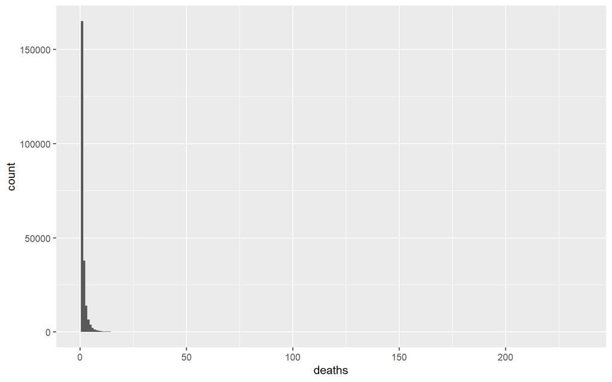

# Filling with zeroes

All possible combinations of `year, month, canton, municipality, age & sex` are used and then empty strata are filled with zeroes.

This expansion also includes municipalities with zero deaths described above.

```r
w_deaths_2015_2021_exp <-
  raum %>%
  select(GMDNAME) %>%
  distinct() %>%
  left_join(w_deaths_2015_2021) %>%
  select(-deaths, -canton) %>%
  # avoiding NAs
  mutate(
    year = if_else(is.na(year), as.integer(2015), year),
    month = if_else(is.na(month), as.integer(1), month),
    sex = if_else(is.na(sex), "Male", sex),
    age = if_else(is.na(age), "<40", age)
  ) %>%
  expand(GMDNAME, year, month, age, sex) %>%
  left_join(w_deaths_2015_2021) %>%
  replace_na(list(deaths = 0)) %>%
  mutate(date = ymd(paste(year, month, "1", sep = " "))) %>%
  relocate(date, .after = month) %>%
  left_join(raum) %>%
  select(-canton) %>%
  relocate(GMDNR, .before = GMDNAME) %>%
  relocate(KTNAME, .after = GMDNAME) %>%
  arrange(GMDNR, year, month, age, sex) %>%
  filter( !(year == 2021 & month > 6))
```

Needless to say that creates large amount of zero cells:

```
deaths == 0 <lgl>
# total N=2024568 valid N=2024568 mean=0.88 sd=0.32

Value |       N | Raw % | Valid % | Cum. %
------------------------------------------
FALSE |  236091 | 11.66 |   11.66 |  11.66
TRUE  | 1788477 | 88.34 |   88.34 | 100.00
<NA>  |       0 |  0.00 |    <NA> |   <NA>
```

Situation only marginally improves with exclusion of `<40` age group stratum:

```
deaths == 0 <lgl>
# total N=1687140 valid N=1687140 mean=0.86 sd=0.34

Value |       N | Raw % | Valid % | Cum. %
------------------------------------------
FALSE |  228355 | 13.54 |   13.54 |  13.54
TRUE  | 1458785 | 86.46 |   86.46 | 100.00
<NA>  |       0 |  0.00 |    <NA> |   <NA>
```

# Examples of time series

## Municipalities Bern & Meienried:

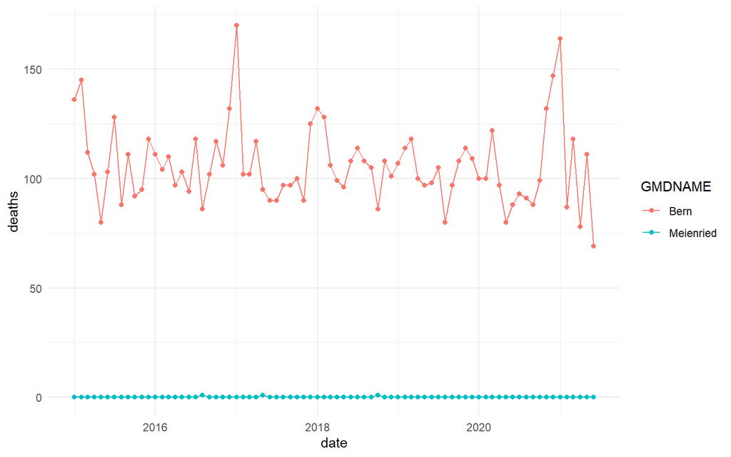

## All time series

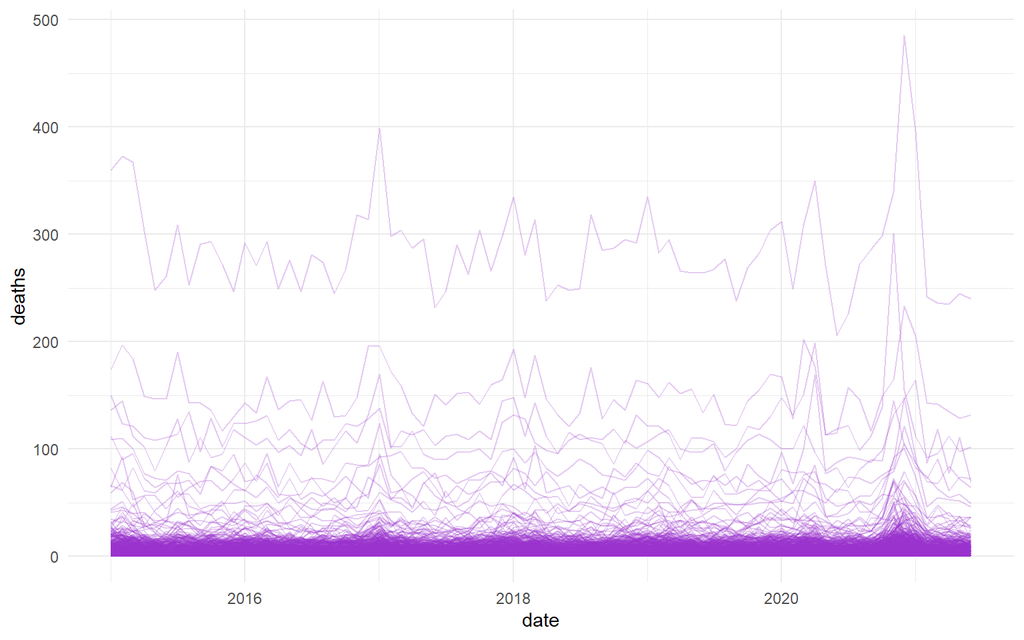

# Groups for stratified modelling

```r
groups = as_tibble(expand_grid(age = c("<40", "40-49", "50-59",
                                       "60-69", "70-79", "80+"),
                               sex = c("Female", "Male")))
```